# Predicting HPV Vaccination Socioeconomic Determinants Using NHANES Data (2021–2023)

BMIN503/EPID600 Final Project

Author

Johanna Momole

## 1 Overview

HPV vaccination is a critical public health measure to reduce HPV-related cancer risk. Despite its efficacy, vaccination rates remain inconsistent across demographic and socioeconomic groups in the U.S. This project explores factors influencing HPV vaccination rates using the NHANES dataset (2021–2023). Specifically, this study examines the effects of insurance coverage, socioeconomic status, and education levels. Predictive modeling and feature importance analyses are conducted to identify key barriers and provide actionable recommendations for public health interventions.

- **Goals**: Understand factors influencing HPV vaccination coverage and predict vaccination outcomes using Logistic Regression and XGBoost.
- **Data**: *NHANES Dataset* (2021–2023) focusing on HPV vaccination, insurance, poverty, and education levels.
- **Faculty Consulted**:
  - Dr. Fuchiang Tsui: Guided the selection of relevant factors and strategies to handle data complexity effectively.
  - Dr. Jesse Hsu: Recommended statistical modeling approaches for analyzing disparities anad predicting trends.

## 2 Introduction

Human papillomavirus (HPV) is the most common sexually transmitted infection in the United States, with significant health implications, including cervical, anal, and oropharyngeal cancers. Despite the availability of a safe and effective vaccine since 2006 for females and 2009 for males, HPV vaccination rates remain suboptimal, particularly among adolescents. In 2022, only 38.6% of children aged 9–17 years had received at least one dose of the HPV vaccine, with disparities evident across racial, socioeconomic, and geographic lines.

This project leverages data from the National Health and Nutrition Examination Survey (NHANES) 2021–2023 to analyze factors influencing HPV vaccination rates. The dataset includes information on key variables such as HPV vaccination status, health insurance coverage, family poverty level, and education level. For instance, vaccination rates among insured children were higher (41.5%) compared to uninsured children (20.7%), reflecting the role of healthcare access. Similarly, vaccination rates vary significantly with family income and parental education levels (Villarroel et al., 2024; Herb, 2024)

The findings of this project have the potential to inform public health policies and initiatives aimed at addressing inequities, increasing vaccination rates, and ultimately reducing HPV-related disease burdens.

## 3 Methods

### 3.1 Load the Libraries

In this project, several R libraries are utilized to perform data manipulation, visualization, and modeling. Below is an overview of the key libraries:

- **tidyverse**: Data wrangling and visualization.
- **nhanesA**: Fetching NHANES datasets.
- **caret**: Model training and evaluation.
- **xgboost**: Gradient boosting for predictive modeling.
- **smotefamily**: Balancing imbalanced datasets using oversampling techniques.
- **Matrix**: Converting dataset into a sparse matrix format for XGBoost modeling.
- **MLmetrics**: Calculating performance metrics such as precision, recall, and F1-score.

```r
# Install necessary packages
install.packages(c("tidyverse", "nhanesA", "caret", "xgboost", "smotefamily", "Matrix", "MLmetrics"))
```

```r
# Load packages
library(tidyverse)
library(nhanesA)
library(caret)
library(xgboost)
library(smotefamily)
library(Matrix)
library(MLmetrics)
```

### 3.2 Load the Dataset

The NHANES dataset (2021–2023) includes HPV vaccination information alongside socioeconomic and demographic variables. Key variables are:

```r
# Load NHANES datasets
immunization_data <- nhanes("IMQ_L")
insurance_data <- nhanes("HIQ_L")
poverty_data <- nhanes("INQ_L")
education_data <- nhanes("DEMO_L")

# Preview datasets
summary(immunization_data)
```

```
      SEQN                          IMQ011            IMQ060
 Min.   :130378   Yes, at least 2 doses:3465   Yes       :1095
 1st Qu.:133358   Less than 2 doses    : 547   No        :1512
 Median :136352   No doses             :5460   Refused   :   2
 Mean   :136346   Refused              :  21   Don't know: 244
 3rd Qu.:139324   Don't know           :2072   NA's      :8712
 Max.   :142310

        IMQ070         IMQ090             IMQ100
 Yes       : 637   Min.   :  1.0   1 Dose    : 387
 No        :1500   1st Qu.: 12.0   2 Doses   : 720
 Refused   :   5   Median : 15.0   3 Doses   : 418
 Don't know: 351   Mean   :242.5   Refused   :   1
 NA's      :9072   3rd Qu.: 34.0   Don't know: 206
                   Max.   :999.0   NA's      :9833
                   NA's   :9833
```

```r
summary(insurance_data)
```

```
      SEQN               HIQ011                              HIQ032A
 Min.   :130378   Yes       :11007   Covered by private insurance:5827
 1st Qu.:133361   No        :  864   Refused                     :  13
 Median :136344   Refused   :   10   Don't know                  : 107
 Mean   :136344   Don't know:   29   NA's                        :5986
 3rd Qu.:139327   NA's      :   23
 Max.   :142310

    HIQ032B        HIQ032C         HIQ032D        HIQ032E         HIQ032F
 Min.   :2      Min.   :3       Min.   :4      Min.   :5       Min.   :6
 1st Qu.:2      1st Qu.:3       1st Qu.:4      1st Qu.:5       1st Qu.:6
 Median :2      Median :3       Median :4      Median :5       Median :6
 Mean   :2      Mean   :3       Mean   :4      Mean   :5       Mean   :6
 3rd Qu.:2      3rd Qu.:3       3rd Qu.:4      3rd Qu.:5       3rd Qu.:6
 Max.   :2      Max.   :3       Max.   :4      Max.   :5       Max.   :6
 NA's   :9157   NA's   :11732   NA's   :9368   NA's   :11839   NA's   :11563
    HIQ032H         HIQ032I             HIQ210
 Min.   :8       Min.   :9       Yes       :  455
 1st Qu.:8       1st Qu.:9       No        :10529
 Median :8       Median :9       Refused   :    2
 Mean   :8       Mean   :9       Don't know:   19
 3rd Qu.:8       3rd Qu.:9       NA's      :  928
 Max.   :8       Max.   :9
 NA's   :10813   NA's   :11482
```

```r
summary(poverty_data)
```

```
      SEQN           INDFMMPI
 Min.   :130378   Min.   :0.000
 1st Qu.:133361   1st Qu.:1.160
 Median :136344   Median :2.160
 Mean   :136344   Mean   :2.529
 3rd Qu.:139327   3rd Qu.:4.000
 Max.   :142310   Max.   :5.000
                  NA's   :2944
                                       INDFMMPC           INQ300
 Monthly poverty level index <= 1.30       :2996   Yes       :4424
 1.30 < Monthly poverty level index <= 1.85:1539   No        :5650
 Monthly poverty level index >1.85         :5660   Refused   : 234
 Refused                                   :  79   Don't know: 160
 Don't know                                : 190   NA's      :1465
 NA's                                      :1469

             IND310
 Less than $3000:3950
 $3001- $5000   : 579
 $5001-$10000   : 485
 $10001-$15000  : 338
 $15001-$20000  : 167
 (Other)        : 131
 NA's           :6283
```

```r
summary(education_data)
```

```
      SEQN           SDDSRVYR                               RIDSTATR
 Min.   :130378   Min.   :12   Interviewed only                 :3073
 1st Qu.:133361   1st Qu.:12   Both interviewed and MEC examined:8860
 Median :136344   Median :12
 Mean   :136344   Mean   :12
 3rd Qu.:139327   3rd Qu.:12
 Max.   :142310   Max.   :12

   RIAGENDR       RIDAGEYR        RIDAGEMN
 Male  :5575   Min.   : 0.00   Min.   : 0.00
 Female:6358   1st Qu.:13.00   1st Qu.: 6.00
               Median :37.00   Median :11.00
               Mean   :38.32   Mean   :11.63
               3rd Qu.:62.00   3rd Qu.:17.00
               Max.   :80.00   Max.   :24.00
                               NA's   :11556
                                RIDRETH1
 Mexican American                   :1117
 Other Hispanic                     :1373
 Non-Hispanic White                 :6217
 Non-Hispanic Black                 :1597
 Other Race - Including Multi-Racial:1629


                                RIDRETH3                           RIDEXMON
 Mexican American                   :1117   November 1 through April 30:4251
 Other Hispanic                     :1373   May 1 through October 31   :4609
 Non-Hispanic White                 :6217   NA's                       :3073
 Non-Hispanic Black                 :1597
 Non-Hispanic Asian                 : 681
 Other Race - Including Multi-Racial: 948

    RIDEXAGM        DMQMILIZ                                   DMDBORN4
 Min.   :  0.0   Yes    : 694   Born in 50 US states or Washington,:10039
 1st Qu.: 66.0   No     :7606   Others                             : 1875
 Median :122.0   Refused:   1   NA's                               :   19
 Mean   :121.9   NA's   :3632
 3rd Qu.:179.5
 Max.   :239.0
 NA's   :9146
```

[output cut: 57 more lines]

```
 Less than high school degree                  : 300   Min.   :  4584
 High school grad/GED or some college/AA degree: 942   1st Qu.: 14332
 College graduate or above                     : 885   Median : 21670
 NA's                                          :9806   Mean   : 27404
                                                       3rd Qu.: 33831
                                                       Max.   :170968

    WTMEC2YR         SDMVSTRA        SDMVPSU         INDFMPIR
 Min.   :     0   Min.   :173.0   Min.   :1.000   Min.   :0.000
 1st Qu.:     0   1st Qu.:176.0   1st Qu.:1.000   1st Qu.:1.180
 Median : 21718   Median :180.0   Median :1.000   Median :2.500
 Mean   : 27404   Mean   :179.9   Mean   :1.492   Mean   :2.708
 3rd Qu.: 38341   3rd Qu.:184.0   3rd Qu.:2.000   3rd Qu.:4.500
 Max.   :227108   Max.   :187.0   Max.   :2.000   Max.   :5.000
                                                  NA's   :2041
```

### 3.3 Data Cleaning

Data cleaning steps included merging datasets, recoding variables, and filtering for complete cases. Specific recoding involved:

- HPV vaccine: Recoded as `1` (Yes) and `2` (No).
- Insurance: Recoded as `1` (Covered) and `2` (Not Covered).
- Poverty: Recoded into `1` (Low income: <$3,000) and `2` (Higher income: ≥$3,000).
- Education: Recoded as `1` (Below college) and `2` (College or above).

```r
# Merge data
merged_data <- list(immunization_data, insurance_data, poverty_data, education_data) |>
  reduce(left_join, by = "SEQN") |>
  select(SEQN, IMQ060, HIQ011, IND310, DMDEDUC2) |>
  rename(
    ID = SEQN,
    HPV_vaccine = IMQ060,
    Insurance = HIQ011,
    Poverty = IND310,
    Education = DMDEDUC2
  ) |>
  mutate(
    HPV_vaccine = case_when(
      HPV_vaccine == "Yes" ~ 1,
      HPV_vaccine == "No" ~ 2,
      TRUE ~ NA_real_
    ),
    Insurance = case_when(
      Insurance == "Yes" ~ 1,
      Insurance == "No" ~ 2,
      TRUE ~ NA_real_
    ),
    Poverty = case_when(
      Poverty == "Less than $3000" ~ 1,
      Poverty == "$3001- $5000" ~ 2,
      Poverty == "$5001-$10000" ~ 2,
      Poverty == "$10001-$15000" ~ 2,
      Poverty == "$15001-$20000" ~ 2,
      TRUE ~ NA_real_
    ),
    Education = case_when(
      Education == "Less than 9th Grade" ~ 1,
      Education == "9-11th grade (Includes 12th grade with no diploma)" ~ 1,
      Education == "High school graduate/GED or equivalent" ~ 1,
      Education == "Some college or AA degree" ~ 2,
      Education == "College graduate or above" ~ 2,
      TRUE ~ NA_real_
    )
  ) |>
  filter(!is.na(HPV_vaccine) & !is.na(Insurance) & !is.na(Poverty) & !is.na(Education))

summary(merged_data)
```

```
       ID          HPV_vaccine     Insurance       Poverty        Education
 Min.   :130380   Min.   :1.00   Min.   :1.00   Min.   :1.000   Min.   :1.000
 1st Qu.:133640   1st Qu.:1.00   1st Qu.:1.00   1st Qu.:1.000   1st Qu.:1.000
 Median :136575   Median :2.00   Median :1.00   Median :1.000   Median :2.000
 Mean   :136469   Mean   :1.61   Mean   :1.13   Mean   :1.298   Mean   :1.655
 3rd Qu.:139424   3rd Qu.:2.00   3rd Qu.:1.00   3rd Qu.:2.000   3rd Qu.:2.000
 Max.   :142300   Max.   :2.00   Max.   :2.00   Max.   :2.000   Max.   :2.000
```

## 4 Results

### 4.1 Descriptive Analysis

**Distribution of HPV Vaccination**

- The bar chart indicates a significantly lower number of individuals who received the HPV vaccine (light blue bar) compared to those who have not (orange bar).
- This disparity could imply the challenges in achieving widespread HPV vaccine uptake. As highlighted in Spencer et al. (2020), financial and logistical barriers, alongside vaccine hesitancy, contribute to low vaccination rates. Additionally, misinformation and lack of awareness about HPV's association with cancer may exacerbate these trends.

```r
# Distribution of HPV vaccination
table(merged_data$HPV_vaccine)
```

```
  1   2
323 506
```

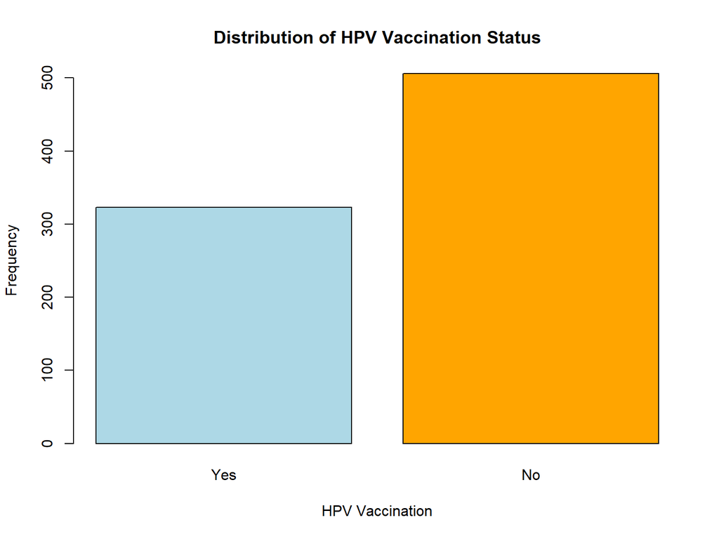

```r
# Visualize the distribution
barplot(
  table(merged_data$HPV_vaccine),
  main = "Distribution of HPV Vaccination Status",
  xlab = "HPV Vaccination",
  ylab = "Frequency",
  col = c("lightblue", "orange"),
  names.arg = c("Yes", "No")
)
```

**Health Insurance Coverage**

- The majority of individuals are covered by health insurance (green bar), with only a small proportion lacking coverage (pink bar).
- Despite high insurance coverage, the low vaccination rate seen earlier suggests that insurance alone may not eliminate barriers. Studies such as Maness and Thompson (2019) have shown that socioeconomic and educational factors, combined with access challenges, also play a crucial role in vaccine uptake. While insurance reduces direct costs, other structural barriers persist.

```r
# Distribution of insurance status
table(merged_data$Insurance)
```

```
  1   2
721 108
```

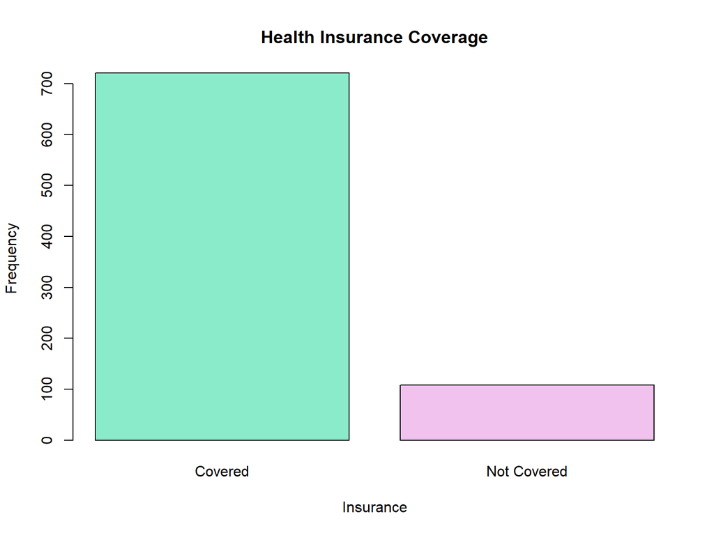

```r
# Visualize health insurance coverage
barplot(
  table(merged_data$Insurance),
  main = "Health Insurance Coverage",
  xlab = "Insurance",
  ylab = "Frequency",
  col = c("#8aebca", "#f1c2ed"),
  names.arg = c("Covered", "Not Covered")
)
```

**Poverty Levels**

- The majority of individuals fall under the "Less than $3000" category (lavender bar), representing lower socioeconomic status, while fewer individuals have savings above $3000 (yellow bar).
- Socioeconomic disadvantage is a significant barrier to healthcare access, including vaccination. Xiong et al. (2024) found a direct correlation between poverty and lower HPV vaccination rates, as financial constraints often deprioritize preventive healthcare.

```r
# Distribution of poverty levels
table(merged_data$Poverty)
```

```
  1   2
582 247
```

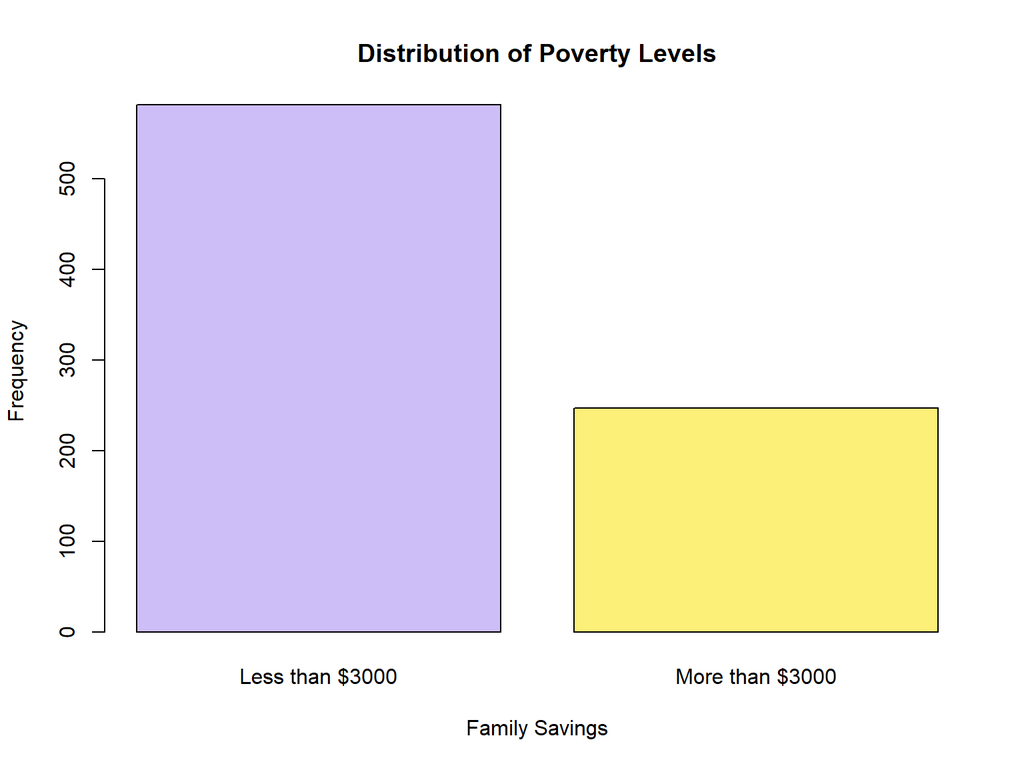

```r
# Visualize poverty levels
barplot(
  table(merged_data$Poverty),
  main = "Distribution of Poverty Levels",
  xlab = "Family Savings",
  ylab = "Frequency",
  col = c("#cebef8", "#fdf079"),
  names.arg = c(
    "Less than $3000",
    "More than $3000"
  )
)
```

**Education Levels**

- A higher proportion of individuals fall into the "College or Above" category (yellow bar) compared to "Below College" (orange bar).
- Higher education levels are typically associated with better awareness and adoption of preventive healthcare measures. However, the gap in vaccination rates, even among educated individuals, might stem from cultural or personal beliefs, as suggested by Villarroel et al. (2024). This emphasizes the need for tailored education campaigns addressing vaccine hesitancy at all educational levels.

```r
# Distribution of education levels
table(merged_data$Education)
```

```
  1   2
286 543
```

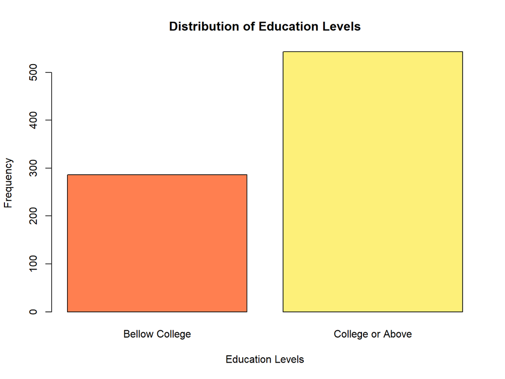

```r
# Visualize education levels
barplot(
  table(merged_data$Education),
  main = "Distribution of Education Levels",
  xlab = "Education Levels",
  ylab = "Frequency",
  col = c("coral", "#fdf079"),
  names.arg = c(
     "Bellow College",
     "College or Above"
  )
)
```

### 4.2 Predictive Analysis

#### 4.2.1 **XGBoost**

- **Purpose**: To achieve high predictive accuracy and effectively model complex relationships.
- **Strengths**:
  - Handles nonlinear interactions between features.
  - Robust to missing data and works well with imbalanced datasets.
  - Provides feature importance scores, helping identify the most influential predictors.
  - Highly efficient, making it suitable for large-scale predictive modeling tasks.

#### 4.2.2 **Logistic Regression**

- **Purpose**: To establish a baseline model and interpret the relationships between socioeconomic factors and HPV vaccination.
- **Strengths**:
  - Simple and interpretable, showing how each factor impacts vaccination likelihood.
  - Useful for understanding key determinants and their statistical significance.
  - Complements XGBoost by providing clarity on predictor effects.

**Data Preparation**

```r
# Showing data imbalance
table(merged_data$HPV_vaccine)
```

```
  1   2
323 506
```

```r
merged_data$HPV_vaccine <- as.factor(merged_data$HPV_vaccine)
levels(merged_data$HPV_vaccine)  # Should show exactly two levels (e.g., "1" and "2")
```

```
[1] "1" "2"
```

```r
# Convert categorical predictors to numeric
smote_data <- merged_data |>
  mutate(
    Insurance = as.numeric(as.factor(Insurance)),
    Poverty = as.numeric(as.factor(Poverty)),
    Education = as.numeric(as.factor(Education))
  )

smote_data <- smote_data |>
  mutate(across(where(is.factor), ~ as.numeric(as.character(.))))

str(smote_data)  # Ensure all predictors are numeric/factor
```

```
'data.frame':   829 obs. of  5 variables:
 $ ID         : num  130380 130388 130390 130391 130395 ...
 $ HPV_vaccine: num  2 1 2 2 2 2 2 2 2 1 ...
 $ Insurance  : num  1 1 2 1 1 1 1 1 1 1 ...
 $ Poverty    : num  1 1 1 1 1 2 1 2 1 2 ...
 $ Education  : num  1 2 1 1 1 1 2 2 2 2 ...
```

```r
# Apply SMOTE
smote_output <- SMOTE(
  X = smote_data[, -which(names(smote_data) == "HPV_vaccine")],  # Exclude target variable
  target = smote_data$HPV_vaccine,  # Target variable
  K = 5,  # Number of nearest neighbors
  dup_size = 2  # Oversampling factor
)

any(is.na(smote_data))  # Ensure no missing values
```

```
[1] FALSE
```

```r
# Separate the majority and minority classes
minority_class <- smote_data |> filter(HPV_vaccine == "1")
majority_class <- smote_data |> filter(HPV_vaccine == "2")

# Oversample the minority class
oversampled_minority <- minority_class[sample(1:nrow(minority_class), nrow(majority_class), replace = TRUE), ]

# Combine the oversampled minority class with the majority class
balanced_data <- bind_rows(majority_class, oversampled_minority)
balanced_data$HPV_vaccine <- as.factor(balanced_data$HPV_vaccine)

# Verify balance
table(balanced_data$HPV_vaccine)
```

```
  1   2
506 506
```

**Data Splitting**

```r
# Ensure all necessary variables are factors
balanced_data <- balanced_data |>
  mutate(
    HPV_vaccine = as.factor(HPV_vaccine),
    Insurance = as.factor(Insurance),
    Poverty = as.factor(Poverty),
    Education = as.factor(Education)
  )

# Split the dataset into training and testing sets (70% train, 30% test)
set.seed(123)
train_index <- sample(1:nrow(merged_data), 0.7 * nrow(balanced_data))
train_data <- balanced_data[train_index, ]
test_data <- balanced_data[-train_index, ]
```

**XGBoost Model**

```r
# Prepare data for XGBoost
train_matrix <- sparse.model.matrix(HPV_vaccine ~ Insurance + Poverty + Education - 1, data = train_data)
test_matrix <- sparse.model.matrix(HPV_vaccine ~ Insurance + Poverty + Education - 1, data = test_data)

train_labels <- as.numeric(train_data$HPV_vaccine) - 1  # XGBoost labels start at 0
test_labels <- as.numeric(test_data$HPV_vaccine) - 1

# Train the XGBoost model
xgb_model <- xgboost(
  data = train_matrix,
  label = train_labels,
  max_depth = 3,
  eta = 0.1,
  nrounds = 100,
  objective = "binary:logistic",
  verbose = 0
)

# Predict probabilities on test data
xgb_probs <- predict(xgb_model, test_matrix)

# Convert probabilities to class predictions
xgb_class <- ifelse(xgb_probs > 0.5, 1, 2)

# Convert predictions and actual labels to factors
xgb_class <- factor(xgb_class, levels = c(1, 2))
test_data$HPV_vaccine <- factor(test_data$HPV_vaccine, levels = c(1, 2))

# Evaluate the model
xgb_conf_matrix <- confusionMatrix(
  data = xgb_class,
  reference = test_data$HPV_vaccine,
  positive = "1"
)

# Extract metrics
xgb_accuracy <- xgb_conf_matrix$overall["Accuracy"]
xgb_precision <- xgb_conf_matrix$byClass["Precision"]
xgb_recall <- xgb_conf_matrix$byClass["Recall"]
xgb_f1_score <- xgb_conf_matrix$byClass["F1"]

# Print results
cat("XGBoost Confusion Matrix:\n")
```

```
XGBoost Confusion Matrix:
```

```r
print(xgb_conf_matrix$table)
```

[output not shown]

```r
cat("\nAccuracy: ", round(xgb_accuracy, 4), "\n")
```

```
Accuracy:  0.7632
```

```r
cat("Precision: ", round(xgb_precision, 4), "\n")
```

```
Precision:  0.7674
```

```r
cat("Recall: ", round(xgb_recall, 4), "\n")
```

```
Recall:  0.9914
```

```r
cat("F1 Score: ", round(xgb_f1_score, 4), "\n")
```

```
F1 Score:  0.8652
```

**Logistic Regression Model**

```r
# Logistic Regression Model
logistic_model <- glm(
  HPV_vaccine ~ Insurance + Poverty + Education,
  family = "binomial",
  data = train_data
)

# Predict probabilities on test data
logistic_probs <- predict(logistic_model, test_data, type = "response")

# Convert probabilities to class predictions
logistic_class <- ifelse(logistic_probs > 0.5, 1, 2)

# Convert predictions and actual labels to factors
logistic_class <- factor(logistic_class, levels = c(1, 2))
test_data$HPV_vaccine <- factor(test_data$HPV_vaccine, levels = c(1, 2))

# Evaluate the model
logistic_conf_matrix <- confusionMatrix(
  data = logistic_class,
  reference = test_data$HPV_vaccine,
  positive = "1"
)

# Extract metrics
logistic_accuracy <- logistic_conf_matrix$overall["Accuracy"]
logistic_precision <- logistic_conf_matrix$byClass["Precision"]
logistic_recall <- logistic_conf_matrix$byClass["Recall"]
logistic_f1_score <- logistic_conf_matrix$byClass["F1"]

# Print results
cat("Logistic Regression Confusion Matrix:\n")
```

```
Logistic Regression Confusion Matrix:
```

```r
print(logistic_conf_matrix$table)
```

```
          Reference
Prediction   1   2
         1 233  71
         2  0   0
```

```r
cat("\nAccuracy: ", round(logistic_accuracy, 4), "\n")
```

```
Accuracy:  0.7664
```

```r
cat("Precision: ", round(logistic_precision, 4), "\n")
```

```
Precision:  0.7664
```

```r
cat("Recall: ", round(logistic_recall, 4), "\n")
```

```
Recall:  1.0000
```

```r
cat("F1 Score: ", round(logistic_f1_score, 4), "\n")
```

```
F1 Score:  0.8678
```

```r
# Compile results into a data frame
results <- data.frame(
  Model = c("XGBoost", "Logistic Regression"),
  Accuracy = c(round(xgb_accuracy, 4), round(logistic_accuracy, 4)),
  Precision = c(round(xgb_precision, 4), round(logistic_precision, 4)),
  Recall = c(round(xgb_recall, 4), round(logistic_recall, 4)),
  F1_Score = c(round(xgb_f1_score, 4), round(logistic_f1_score, 4))
)

# Display the model comparison
cat("\nModel Comparison:\n")
```

```
Model Comparison:
```

```r
results
```

```
                Model Accuracy Precision Recall F1_Score
1             XGBoost   0.7632    0.7674 0.9914   0.8652
2 Logistic Regression   0.7664    0.7664 1.0000   0.8678
```

## 5 Discussion

### 5.1 **Feature Importance Analysis**

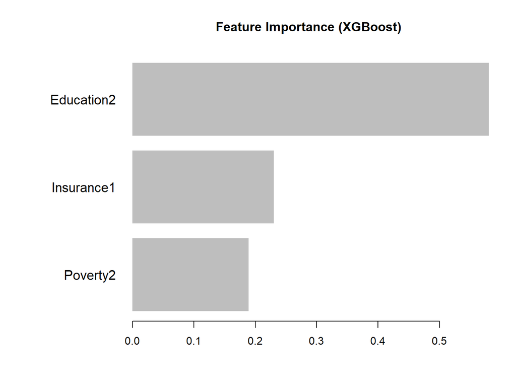

```r
# Extract feature importance
xgb_importance <- xgb.importance(model = xgb_model)

# Visualize feature importance
xgb.plot.importance(xgb_importance, main = "Feature Importance (XGBoost)")
```

- The feature importance is based on the gain, which measures the contribution of each feature to the model's decision-making.
- The most important feature is:
  - **Education**: Plays the largest role in predicting the outcome, with a relative importance score nearing 0.6. This aligns with literature that suggests individuals with more education may have better access to healthcare information and preventive measures. Still, counter-intuitively, they might also have specific concerns or misconceptions about vaccine importance.
- **Insurance**: The second most influential feature in the XGBoost model, with an importance score of approximately 0.2. Insurance often determines access to preventive care, such as HPV vaccines, and uninsured populations are less likely to complete vaccination regimens due to financial constraints.
- **Poverty**: Although ranked third, poverty still contributes notably to the model. Economic barriers significantly impact vaccination coverage, as families in porverty often face challenges like cost, accessibility, and healthcare literacy.

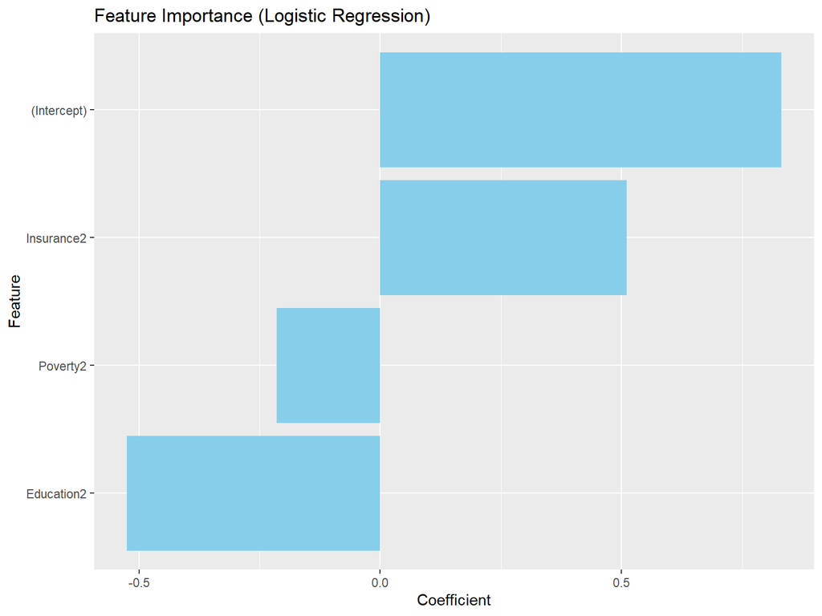

```r
# Extract coefficients from the logistic regression model
logistic_coefficients <- summary(logistic_model)$coefficients

# Organize into a dataframe
logistic_importance <- data.frame(
  Feature = rownames(logistic_coefficients),
  Coefficient = logistic_coefficients[, "Estimate"]
)

# Sort by the absolute value of the coefficient for importance
logistic_importance <- logistic_importance[order(abs(logistic_importance$Coefficient), decreasing = TRUE), ]

# Visualize feature importance
library(ggplot2)
ggplot(logistic_importance, aes(x = reorder(Feature, Coefficient), y = Coefficient)) +
  geom_bar(stat = "identity", fill = "skyblue") +
  coord_flip() +
  labs(title = "Feature Importance (Logistic Regression)", x = "Feature", y = "Coefficient")
```

## 7 Recommendations

#### 7.1 **Improve Insurance Coverage**

- **Finding**: Having health insurance is one of the strongest predictors of HPV vaccination as individuals with coverage are more likely to access preventative healthcare services.
- **Recommendations**:
  - Advocate for the inclusion of HPV vaccines in all insurance policies, including short-term and high-deductible plans, through policy reform.
  - Partner with Medicaid and CHIP (Children's Health Insurance Program) to offer free HPV vaccines in underserved areas.
  - Develop campaigns to ensure families are aware of insurance benefits covering HPV vaccines, focusing on outreach in areas with low insurance penetration.

#### 7.2 **Address Poverty-Related Barriers**

- **Finding**: Individuals from higher poverty levels are less likely to receive vaccinations.
- **Recommendations**:
  - Provide vouchers for groceries, school supplies, or public transit to families completing the HPV vaccine series.
  - Set up mobile vaccination clinics in economically disadvantaged areas, reducing logistical and financial barriers.
  - Integrate HPV vaccination programs into school health clinics in low-income regions.

#### 7.3 **Improve Educational Outreach**

- **Finding**: Misinformation and lack of awareness about HPV vaccination contribute to hesitancy, even amon educated individuals.
- **Recommendations**:
  - Focus outreach in communities with lower vaccination rates, explaining the vaccine's safety and effectiveness.
  - Collaborate with trusted local organizations, such as schools, churches, and parent-teacher associations, to disseminate accurate information.
  - Use social media platforms, infographics, and testimonials from healthcare providers to address vaccine myths and fears effectively.

#### 7.4 **Target Regional Disparities with Localized Strategies**

- **Finding**: Regional disparities reflect differences in healthcare access, availability of providers, and local socioeconomic conditions.
- **Recommendations**:
  - Develop geospatial maps to identify vaccination gaps in rural and underserved regions.
  - Deploy mobile clinics to rural areas experiencing healthcare shortages.
  - Collaborate with local healthcare providers to create culturally sensitive campaigns addressing unique regional concerns.

#### 7.5 **Advocate for Policy Interventions**

- **Finding**: Broader systemic changes are needed to ensure equitable vaccine access.
- **Recommendations**:
  - Lobby for school-entry HPV vaccine mandates, similar to other routine childhood vaccinations.
  - Secure federal and state funding for public health campaigns, with a focus on low-income and rural populations.
  - Create partnerships with healthcare providers to integrate HPV vaccine recommendations into routine pediatric check-ups and adolescent healthcare.

## 8 References

- Han, J. J., Tarney, C. M., & Song, J. (2017). Variation in genital human papillomavirus infection prevalence and vaccination coverage among men and women in the USA. Future Oncology, 13(13), 1129–1132. https://doi.org/10.2217/fon-2017-0147
- Herb, S. (2024). Relationship Between Geographic Location, Race, and Socioeconomic Status on Adolescent Male HPV Vaccination in the United States.[Doctoral dissertation, Walden University]. Walden Dissertations and Doctoral Studies. https://scholarworks.waldenu.edu/dissertations/16240/
- Maness, S. B., & Thompson, E. L. (2019). Social Determinants of Human Papillomavirus Vaccine Uptake: An Assessment of Publicly Available Data. Public Health Reports, 134(3), 264–273. https://doi.org/10.1177/0033354919838219
- Quinlan, J. D. (2021). Human Papillomavirus: Screening, Testing, and Prevention. American Family Physician, 104(2), 152–159.
- Spencer, J. C., Brewer, N. T., Trogdon, J. G., Weinberger, M., Coyne-Beasley, T., & Wheeler, S. B. (2020). Cost-effectiveness of Interventions to Increase HPV Vaccine Uptake. Pediatrics, 146(6). https://doi.org/10.1542/peds.2020-0395
- Villarroel, M. A., Galinsky, A. M., Lu, P. J., & Pingali, C. (2024). Human Papillomavirus Vaccination Coverage in Children Ages 9-17 Years: United States, 2022. NCHS Data Brief, 495, 1–8.
- Xiong, S., Humble, S., Barnette, A., Brandt, H., Thompson, V., Klesges, L. M., & Silver, M. I. (2024). Associations of geographic-based socioeconomic factors and HPV vaccination among male and female children in five US states. BMC Public Health, 24(1), 1–8. https://doi.org/10.1186/s12889-024-18206-5
- Yang, H., Xie, Y., Guan, R., Zhao, Y., Lv, W., Liu, Y., Zhu, F., Liu, H., Guo, X., Tang, Z., Li, H., Zhong, Y., Zhang, B., & Yu, H. (2022). Factors affecting HPV infection in U.S. and Beijing females: A modeling study. Frontiers in Public Health, 10. https://doi.org/10.3389/fpubh.2022.1052210